# Preregistration for Baseline People’s Habit Survey Data Collection and Analysis

Xiuyuan Zhang and Dan Yurovsky

10/31/2018

This script contains codes that we plan to use for our next collection of data on participants’ prevalence estimation of people’s habits.

### Load libraries

```r
library(tidyverse)
library(lubridate)
library(lme4)
library(DT)
library(ggpirate)
library(gridExtra)
library(knitr)
library(tidyboot)
library(Matrix)
library(effsize)
library(pwr)
library(compute.es)

theme_set(theme_classic(base_size = 14))
```

### Read in Zip Code - Population Density Data

We read in population density data that helps us map zip code information document collected from participants to density measures.

```r
zip_data <- read_csv("data/Zipcode-ZCTA-Population-Density-And-Area-Unsorted.csv") %>%
  rename(zip = `Zip/ZCTA`, density = `Density Per Sq Mile`)
```

### Read in anonymized data

We read in anonymized data (see `103118_preregistration_process_raw_data.R` for criterion applied to drop certain columns for privacy reasons)

```r
data_novel <- read_csv("data/10312018_people_habit_anonymized_data.csv")
```

The total number of participants we get is 968.

### Applying filtering Criterion

#### Pass attention check

We set an attention check question at the end of our survey, asking participants to select four questions out of all questions they’ve seen previously in our survey. If participants fail the attention check(don’t select all four correct questions), we will drop them from our sample.

```r
attnCheckAnswers <- c('drink coffee','cook at home', 'go to the gym', 'drive to work')

qualtrics_filtered <- data_novel %>%
    rowwise() %>%
  mutate(attention_check = (strsplit(attention_check, ','))) %>%
  mutate(attnTrue = sum(attention_check %in% attnCheckAnswers),
         attnFalse= sum(!attention_check %in% attnCheckAnswers))%>%
  filter(attnFalse==0)
```

Filter peole who passed the attention check, result: n = 773 (out of 968 )

#### Gender & Age filtering

```r
tidy_data <- qualtrics_filtered %>%
  filter(gender != "Other/Non-conforming") %>%
  mutate(gender = factor(gender, levels = c("Female", "Male"), labels = c("female", "male")))

tidy_data %>%
  group_by(gender) %>%
  summarise(n = n()) %>%
  kable()
```

| gender | n |
| --- | --- |
| female | 393 |
| male | 377 |

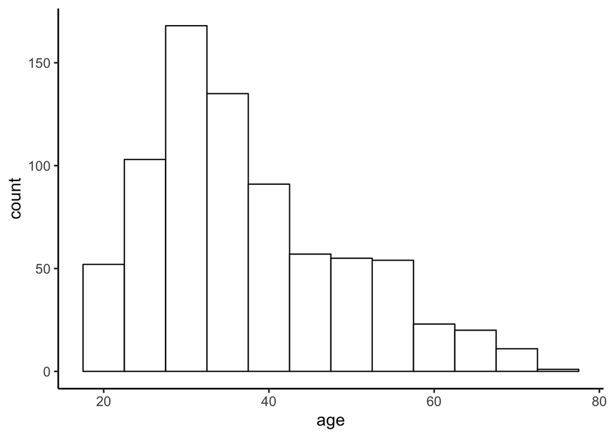

```r
tidy_data %>%
  ggplot(aes(x = age)) +
  geom_histogram(binwidth = 5, fill = "white", color = "black")
```

```r
filtered_data <- tidy_data %>%
  filter(age < 60) %>%
  mutate(age_bin = ifelse(age > median(tidy_data$age), "older", "younger")) %>%
  left_join(zip_data) %>%
  ungroup() %>%
  mutate(dense = factor(density > median(density, na.rm = T),
                         labels = c("sparse", "dense")))

filtered_data %>%
  group_by(gender, age_bin) %>%
  summarise(n = n(), age = mean(age)) %>%
  kable()
```

| gender | age_bin | n | age |
| --- | --- | --- | --- |
| female | older | 180 | 45.65000 |
| female | younger | 188 | 28.41489 |
| male | older | 128 | 45.00000 |
| male | younger | 230 | 28.73913 |

By filtering to participants who selected “Other/Non-conforming” for gender, we lost 3 people.

By filtering to participants younger than 60 years old, we lost 44 people

### Exploratory Data Analysis

#### Scaling Data

From our previous data, we found that participants from different demographic groups have the tendency to scale their responses differently. Since we want to measure differences in participants’ percentage judgement due to possible different background information rather than differences caused by their scaling differences, we will scale participant responses with regard to each of the demographic groups.

```r
# organize data in long format
long_data <- filtered_data %>%
  rename(politics = politics_1) %>%
  select(big_cities_1:drink_coffee_1,gender:politics, density, id) %>%
  gather(question, response, big_cities_1:drink_coffee_1) %>%
  gather(demo, status, gender:politics, density )

# scaling the data
scaled_data <- long_data %>%
  group_by(demo, status) %>%
  mutate(response = scale(response)) %>%
  ungroup()

combinations <- expand.grid(demo = distinct(scaled_data,demo) %>% pull(),
                           question = distinct(scaled_data,question) %>% pull()) %>%
  mutate_all(as.character)
```

#### Analyze effect size

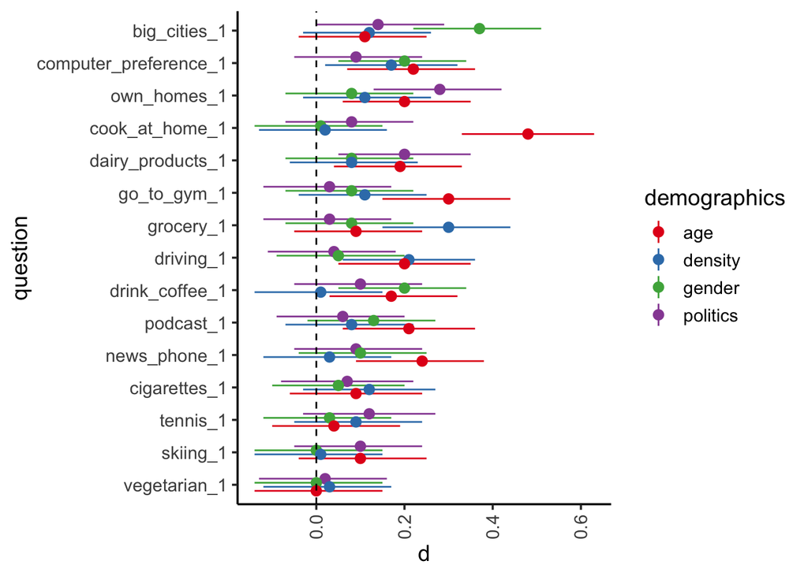

```r
# function to calculate the effect size for our data
effect_size <- function(df, d, q) {

  sub_df <- df %>%
    filter(question == q, demo == d)

  unique_status <- distinct(sub_df, status) %>% pull()

  if(length(unique_status) > 2) {
    cor <- cor(sub_df$response, as.numeric(sub_df$status), use = "complete") %>% abs
    es <- res(r = cor, n = nrow(sub_df), verbose = F)
    pw = pwr.r.test(n = nrow(sub_df),r = cor, sig.level = 0.05)
    #pw_est = pwr.r.test(r = cor, sig.level = 0.05, power = 0.9)
  } else {
    means <- sub_df %>%
      group_by(status) %>%
      summarise(mean = mean(response), sd = sd(response), n = n()) %>%
      as.data.frame() %>%
      arrange(desc(mean))

    es <- mes(means[1, "mean"], means[2, "mean"],
              means[1, "sd"], means[2, "sd"],
              means[1, "n"], means[2, "n"],
              verbose = F)
    pw = pwr.2p2n.test(h = es$d, n1 = means[1, "n"],
                       n2 =  means[2, "n"], sig.level = 0.05)
    #pw_est = pwr.2p.test(h = es$d, sig.level = 0.05, power = 0.9)

  }

    data.frame(demographics = d, question = q, d = es$d,
               lower = es$l.d, upper = es$u.d, pwr = pw$power ) %>%
      as_data_frame()
}

#estimate_n_0.8 = pw_est$n
es <- map2(combinations$demo, combinations$question,
     ~effect_size(scaled_data, .x, .y)) %>%
  bind_rows()

q_ranking <- es %>%
  group_by(question) %>%
  summarise(d = mean(d)) %>%
  arrange(d)

d_ranking <- es %>%
  group_by(demographics) %>%
  summarise(d = mean(d)) %>%
  arrange(d)

es %>%
  mutate(question = factor(question, levels = q_ranking$question),
         demo = factor(demographics, levels = d_ranking$demographics)) %>%
  ggplot(aes(x = question, y = d, ymin = lower, ymax = upper, color = demographics)) +
  geom_pointrange(position = position_dodge(.5)) +
  theme(axis.text.x=element_text(angle=90 ,vjust = .5)) +
  scale_color_brewer(palette = "Set1")  +
  coord_flip() +
  geom_hline(aes(yintercept = 0), linetype = "dashed")
```